#### CSE 9099o Final Hackathon Batch 81 A

**Name :** Sai Vivek Kanukuntla **Enrollment_Id :** 3679

```python
First_Name = "Sai Vivek"
Last_Name = "Kanukuntla"
Enrollment_Id = "3679"
```

# ROBUST YIELD PREDICTION OF VARIOUS FARM PROCESSING UNITS.

## Problem Statement :

A new fast food chain is seeing rapid expansion over the past couple of years. They are now trying to optimize their supply chain to ensure that there are no shortages of ingredients. For this, they’ve tasked the data science team to come up with a model that could predict the output of each food processing farm over the next few years. These predictions could further increase the efficiency of their current supply chain management systems.

### Domain : Agriculture

**Agriculture, Supply Chain Management (SCM)** implies managing the relationships between the businesses responsible for the efficient production and supply of products from the farm level to the consumers to meet consumers requirements reliably in terms of quantity, quality and price.

In Agriculture, Machine Learning techniques are used in crop management processes, following with farming conditions(Weather). In farming, they are used to predict yield and quality of crops as well as livestock production.

### Dataset(s) Description :

*1)train_data.csv :* Consists of Crop Information, The dataset is mainly around different types of ingredients

*Fields:*

● date: The timestamp at which the yield of the food processing farm was measured

● farm_id: The farm identifier that recognizes the farm food processing plant

● ingredient_type: The type of ingredient being produced

● yield: The yield of the plant in tonnes

*2)farm_data.csv:* Consists of the Farm Data and Field Management Information

##### Fields:

● farm_id: The farm identifier that recognizes the farm food processing plant.

● operations_commencing_year: The founding year when the operations commenced on the farm and food processing plant.

● num_processing_plants: The number of processing plants present on the farm.

● farm_area: The area of the farm in square meters.

● farming_company: The company that owns the farms.

● deidentified_location: The location at which the farm is present.

*3)train_weather.csv:* Consists information of the weather data provided by timestamp for each location where the farms are present.

##### Fields:

● time_stamp: The timestamp at which the yield of the food processing farm was measured.

● deidentified_location: The location at which the farm is present.

● temp_obs : Observed daily weather temperatures in C` and it's effect

● cloudiness : the state of the sky when it is covered by clouds and overcast weather, measured in Oktas in the range 0 to 9

● wind_direction : Wind direction is usually the direction from which it originates,Reported in degrees

● dew_temp : Temperature to which the air have to be cooled in order to reach saturation.

● pressure_sea_level : It is the pressure within the atmosphere of Earth, Data points available in Millibars.

● precipitation : Condensation from atmospheric water vapor - includes Rain , Data present in mm/day.

● wind_speed : Quantity caused by air moving from high to low pressure, usually due to changes in temperature , Measured in Km/hr

*4)test_data.csv* and *5)test_weather.csv* will also provided to us further.

### Objectives :

**1.** Explore the data and engineer new features.

**2.** Predict the yield for each farm during the given timestamps.

**3.** Given the forecasted demand for the next few months for a particular ingredient, device a strategy to source it, Creating a strategy to source ‘ing_w’ ingredient type .

# Exploratory Data Analysis -

### Import all the required libraries and setting up the working directory to read the dataset(s) files.

```python
#Necessary Imports
import os
import pandas as pd
import numpy as np
import datetime

import warnings
warnings.filterwarnings('ignore')

import seaborn as sns
import matplotlib.pyplot as plt
%matplotlib inline
```

Set the Working Directory

```python
os.getcwd()
```

```
'/home/3679b81a/PHD_FINAL HACK_ROBUST YIELD PREDICTION OF FARM PROCESSING UNIT_CSE 9099'
```

```python
os.chdir('/home/datasets/lab/CSE9099_FinalHack')
```

```python
os.listdir('/home/datasets/lab/CSE9099_FinalHack')
```

```
['train_weather.csv', 'traindata_without_target.csv', 'farm_data.csv']
```

Reading the Datasets from the given path

```python
train_data = pd.read_csv('traindata_without_target.csv')
train_weather = pd.read_csv('train_weather.csv')
farm_data = pd.read_csv('farm_data.csv')
```

```python
train_data.head()
```

|  | date | farm_id | ingredient_type |
| --- | --- | --- | --- |
| 0 | 2016-01-01 00:00:00 | fid_110884 | ing_w |
| 1 | 2016-01-01 00:00:00 | fid_90053 | ing_w |
| 2 | 2016-01-01 00:00:00 | fid_17537 | ing_w |
| 3 | 2016-01-01 00:00:00 | fid_110392 | ing_w |
| 4 | 2016-01-01 00:00:00 | fid_62402 | ing_w |

```python
train_weather.head()
```

|  | timestamp | deidentified_location | temp_obs | cloudiness | wind_direction | dew_temp | pressure_sea_level | precipitation | wind_speed |
| --- | --- | --- | --- | --- | --- | --- | --- | --- | --- |
| 0 | 2016-01-01 00:00:00 | location 7369 | 25.0 | 6.0 | 0.0 | 20.0 | 1019.7 | NaN | 0.0 |
| 1 | 2016-01-01 01:00:00 | location 7369 | 24.4 | NaN | 70.0 | 21.1 | 1020.2 | -1.0 | 1.5 |
| 2 | 2016-01-01 02:00:00 | location 7369 | 22.8 | 2.0 | 0.0 | 21.1 | 1020.2 | 0.0 | 0.0 |
| 3 | 2016-01-01 03:00:00 | location 7369 | 21.1 | 2.0 | 0.0 | 20.6 | 1020.1 | 0.0 | 0.0 |
| 4 | 2016-01-01 04:00:00 | location 7369 | 20.0 | 2.0 | 250.0 | 20.0 | 1020.0 | -1.0 | 2.6 |

```python
train_weather.tail()
```

|  | timestamp | deidentified_location | temp_obs | cloudiness | wind_direction | dew_temp | pressure_sea_level | precipitation | wind_speed |
| --- | --- | --- | --- | --- | --- | --- | --- | --- | --- |
| 139768 | 2016-12-31 19:00:00 | location 5150 | 3.0 | NaN | 180.0 | -8.0 | NaN | NaN | 5.7 |
| 139769 | 2016-12-31 20:00:00 | location 5150 | 2.8 | 2.0 | 180.0 | -8.9 | 1007.4 | NaN | 7.7 |
| 139770 | 2016-12-31 21:00:00 | location 5150 | 2.8 | NaN | 180.0 | -7.2 | 1007.5 | NaN | 5.1 |
| 139771 | 2016-12-31 22:00:00 | location 5150 | 2.2 | NaN | 170.0 | -6.7 | 1008.0 | NaN | 4.6 |
| 139772 | 2016-12-31 23:00:00 | location 5150 | 1.7 | NaN | 180.0 | -5.6 | 1008.5 | -1.0 | 8.8 |

```python
farm_data.head()
```

|  | farm_id | operations_commencing_year | num_processing_plants | farm_area | farming_company | deidentified_location |
| --- | --- | --- | --- | --- | --- | --- |
| 0 | fid_110884 | 2008.0 | NaN | 690.455096 | Obery Farms | location 7369 |
| 1 | fid_90053 | 2004.0 | NaN | 252.696160 | Obery Farms | location 7369 |
| 2 | fid_17537 | 1991.0 | NaN | 499.446528 | Obery Farms | location 7369 |
| 3 | fid_110392 | 2002.0 | NaN | 2200.407555 | Obery Farms | location 7369 |
| 4 | fid_62402 | 1975.0 | NaN | 10833.140121 | Obery Farms | location 7369 |

### 1) Identification of Varibales and Datatypes

```python
train_data.dtypes
```

```
date               object
farm_id            object
ingredient_type    object
dtype: object
```

```python
print(train_data.shape)
```

```
(20216100, 3)
```

```python
## What are the data types?
train_weather.dtypes
```

```
timestamp                 object
deidentified_location     object
temp_obs                 float64
cloudiness               float64
wind_direction           float64
dew_temp                 float64
pressure_sea_level       float64
precipitation            float64
wind_speed               float64
dtype: object
```

```python
print(train_weather.shape)
```

```
(139773, 9)
```

```python
farm_data.dtypes
```

```
farm_id                        object
operations_commencing_year    float64
num_processing_plants         float64
farm_area                     float64
farming_company                object
deidentified_location          object
dtype: object
```

```python
print(farm_data.shape)
```

```
(1449, 6)
```

### 2) Summary Statistics and Distribution of the Numeric and Categorical Columns

```python
# Distribution of the categorical variables levels .
train_data.describe(include = ['object'])
```

|  | date | farm_id | ingredient_type |
| --- | --- | --- | --- |
| count | 20216100 | 20216100 | 20216100 |
| unique | 8784 | 1434 | 4 |
| top | 2016-12-27 22:00:00 | fid_63700 | ing_w |
| freq | 2370 | 51227 | 12060910 |

```python
train_weather.describe(include = ['object'])
```

|  | timestamp | deidentified_location |
| --- | --- | --- |
| count | 139773 | 139773 |
| unique | 8784 | 16 |
| top | 2016-12-20 03:00:00 | location 7369 |
| freq | 16 | 8784 |

```python
farm_data.describe(include = ['object'])
```

|  | farm_id | farming_company | deidentified_location |
| --- | --- | --- | --- |
| count | 1449 | 1449 | 1449 |
| unique | 1434 | 16 | 16 |
| top | fid_63700 | Obery Farms | location 5290 |
| freq | 2 | 549 | 274 |

```python
# Distribution of the Numerical Columns.
train_weather.describe()
```

|  | temp_obs | cloudiness | wind_direction | dew_temp | pressure_sea_level | precipitation | wind_speed |
| --- | --- | --- | --- | --- | --- | --- | --- |
| count | 139718.000000 | 70600.000000 | 133505.000000 | 139660.000000 | 129155.000000 | 89484.000000 | 139469.000000 |
| mean | 14.418106 | 2.149306 | 180.526632 | 7.350158 | 1016.158038 | 0.983047 | 3.560527 |
| std | 10.626595 | 2.599150 | 111.523629 | 9.790235 | 7.629684 | 8.463678 | 2.335874 |
| min | -28.900000 | 0.000000 | 0.000000 | -35.000000 | 968.200000 | -1.000000 | 0.000000 |
| 25% | 7.200000 | 0.000000 | 80.000000 | 0.600000 | 1011.800000 | 0.000000 | 2.100000 |
| 50% | 15.000000 | 2.000000 | 190.000000 | 8.300000 | 1016.400000 | 0.000000 | 3.100000 |
| 75% | 22.200000 | 4.000000 | 280.000000 | 14.400000 | 1020.800000 | 0.000000 | 5.000000 |
| max | 47.200000 | 9.000000 | 360.000000 | 26.100000 | 1045.500000 | 343.000000 | 19.000000 |

```python
farm_data.describe()
```

|  | operations_commencing_year | num_processing_plants | farm_area |
| --- | --- | --- | --- |
| count | 675.000000 | 355.000000 | 1449.000000 |
| mean | 1967.957037 | 7.740845 | 8557.460363 |
| std | 31.054030 | 3.333683 | 10290.860757 |
| min | 1900.000000 | 5.000000 | 26.291549 |
| 25% | 1949.000000 | 5.000000 | 2137.883836 |
| 50% | 1970.000000 | 7.000000 | 5357.994719 |
| 75% | 1995.000000 | 9.000000 | 10746.647428 |
| max | 2017.000000 | 30.000000 | 81290.125000 |

### 3) Univariate Analysis

Train Data -

```python
#Train Dataset unique value count analysis.
train_data.nunique(axis = 0, dropna = False)
```

```
date               8784
farm_id            1434
ingredient_type       4
dtype: int64
```

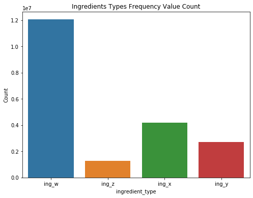

```
ing_w    59.659925
ing_x    20.688659
ing_y    13.398791
ing_z     6.252625
Name: ingredient_type, dtype: float64
```

```python
# Graphical analysis of ingredient types.
plt.figure(figsize=(8,6))
plt.title("Ingredients Types Frequency Value Count")
sns.countplot(x="ingredient_type", data= train_data)
plt.ylabel("Count")
plt.show()

#Unique value count of the ingredient_type column
train_data.ingredient_type.value_counts(normalize = True)*100
```

The ingredient type **"ing_w"** has top occuruning value of 60%, which means that the data is mainly around the ingredient type **"ing_w"**

```python
train_data.farm_id.value_counts()
```

```
fid_63700     51227
fid_68761     41733
fid_103446    35136
fid_109814    35136
fid_122174    35135
              ...
fid_60652      2657
fid_118770     2327
fid_73322      1685
fid_20058      1012
fid_19864       479
Name: farm_id, Length: 1434, dtype: int64
```

```python
train_data.date.value_counts()
```

```
2016-12-27 22:00:00    2370
2016-12-27 17:00:00    2369
2016-12-27 21:00:00    2369
2016-12-27 19:00:00    2369
2016-12-27 20:00:00    2369
                       ...
2016-02-26 01:00:00    1887
2016-02-23 09:00:00    1871
2016-03-23 16:00:00    1822
2016-03-13 03:00:00    1767
2016-03-13 02:00:00    1557
Name: date, Length: 8784, dtype: int64
```

Farm Data -

```python
# Farm Dataset unique value count analysis.
farm_data.nunique(axis = 0 , dropna = False)
```

```
farm_id                       1434
operations_commencing_year     117
num_processing_plants           19
farm_area                     1397
farming_company                 16
deidentified_location           16
dtype: int64
```

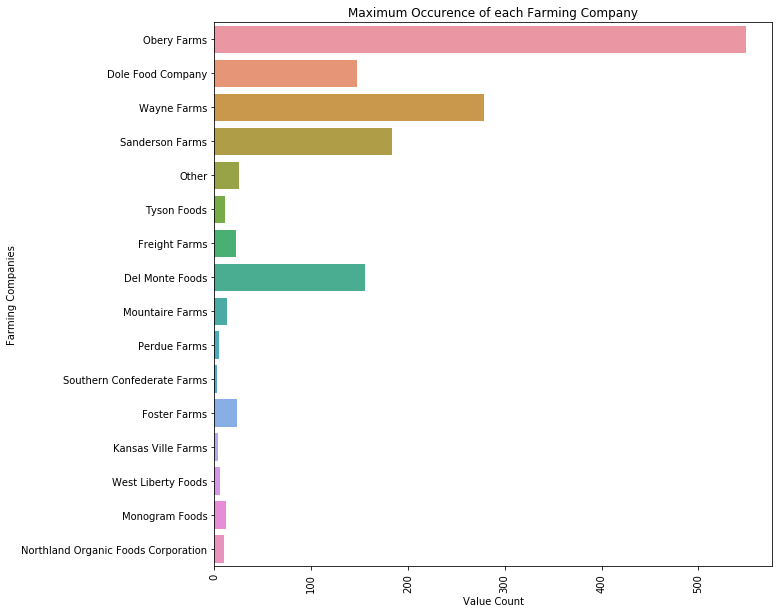

```
Obery Farms                            549
Wayne Farms                            279
Sanderson Farms                        184
Del Monte Foods                        156
Dole Food Company                      147
Other                                   25
Foster Farms                            23
Freight Farms                           22
Mountaire Farms                         13
Monogram Foods                          12
Tyson Foods                             11
Northland Organic Foods Corporation     10
West Liberty Foods                       6
Perdue Farms                             5
Kansas Ville Farms                       4
Southern Confederate Farms               3
Name: farming_company, dtype: int64
```

```python
#Countplot to display the observations/max occurence in 'farming_company' column
plt.figure(figsize=(10,10))
sns.countplot(y="farming_company", data= farm_data )
plt.title("Maximum Occurence of each Farming Company")
plt.ylabel("Farming Companies")
plt.xlabel("Value Count")
plt.xticks(rotation=90)
plt.show()

#Unique value count of the farming_company column
farm_data.farming_company.value_counts()
```

From the above visualization it is clear that the Top 5 farming companies contributing to the growth are **1)Obery Farms** **2)Wayne Farms** **3)Sanderson Farms** **4)Del Monte Foods** **&** **5) Dole Food Company**

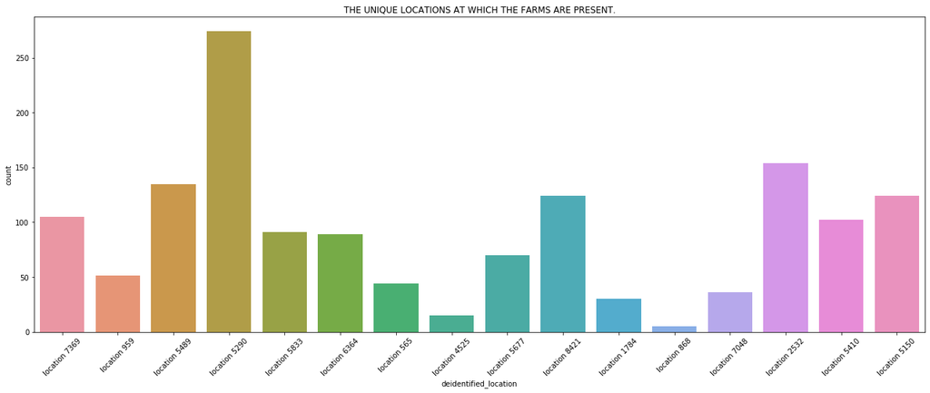

```
location 5290    274
location 2532    154
location 5489    135
location 5150    124
location 8421    124
location 7369    105
location 5410    102
location 5833     91
location 6364     89
location 5677     70
location 959      51
location 565      44
location 7048     36
location 1784     30
location 4525     15
location 868       5
Name: deidentified_location, dtype: int64
```

```python
#Count Plot to display the Unique locations
plt.figure(figsize=(22,8))
sns.countplot(x="deidentified_location", data= farm_data)
plt.title("THE UNIQUE LOCATIONS AT WHICH THE FARMS ARE PRESENT.")
plt.xticks(rotation = 45)
plt.show()

# Value count of unique locations
farm_data.deidentified_location.value_counts()
```

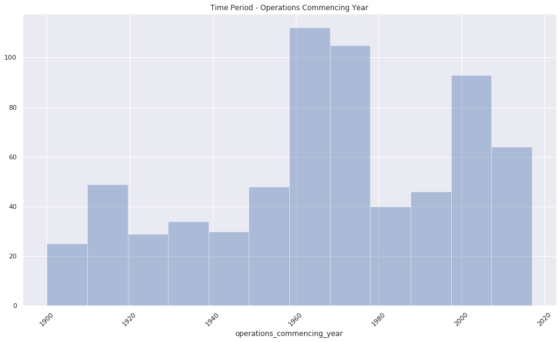

```python
#Plot for distribution of the Operations Commencing Year to check the time period.
plt.figure(figsize=(16,9))
sns.set(style="darkgrid")
sns.distplot(farm_data['operations_commencing_year'],kde = False, hist = True)
plt.xticks(rotation=45)
plt.title('Time Period - Operations Commencing Year')
plt.show()
```

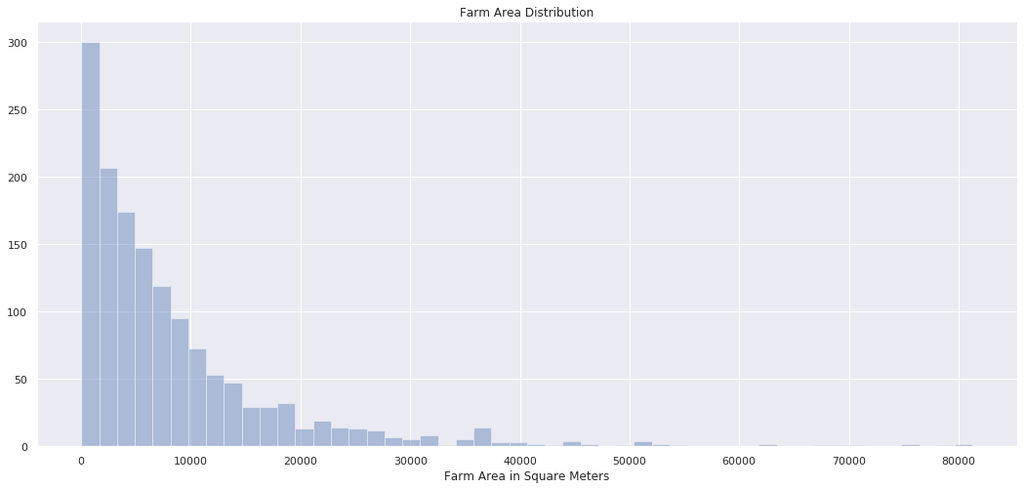

```python
#Plot for distribution of Farm Area.
plt.figure(figsize=(18,8))
sns.set(style="darkgrid")
sns.distplot(farm_data['farm_area'], kde = False)

plt.xlabel("Farm Area in Square Meters")
plt.xticks(rotation= 0)

plt.title('Farm Area Distribution')
plt.show()
```

The area of the farms are mostly in the interval (0 - 10,000) square meters. It tells us that many data points are in that bin.

```python
farm_data.num_processing_plants.value_counts()
```

```
5.0     109
6.0      67
8.0      37
7.0      33
9.0      25
10.0     25
12.0     19
11.0     14
13.0      8
15.0      5
14.0      4
16.0      2
17.0      2
23.0      1
30.0      1
18.0      1
25.0      1
20.0      1
Name: num_processing_plants, dtype: int64
```

Weather Data -

```python
# Train Weather Dataset Analysis
train_weather.nunique(axis = 0, dropna = False)
```

```
timestamp                8784
deidentified_location      16
temp_obs                  620
cloudiness                 11
wind_direction             44
dew_temp                  523
pressure_sea_level        710
precipitation             129
wind_speed                 59
dtype: int64
```

```python
train_weather.deidentified_location.value_counts()
```

```
location 7369    8784
location 5677    8784
location 2532    8783
location 5489    8783
location 5833    8783
location 1784    8782
location 565     8782
location 5290    8780
location 8421    8780
location 5410    8777
location 959     8763
location 6364    8755
location 7048    8755
location 4525    8614
location 868     8614
location 5150    8454
Name: deidentified_location, dtype: int64
```

### 4) Multivariate Analysis and Observation

Farm Data -

```python
# The Average Farm area of each company?
df = farm_data.groupby(['farming_company'])['farm_area'].mean().reset_index()
#df.reset_index()
df.sort_values('farm_area', ascending = False)
```

|  | farming_company | farm_area |
| --- | --- | --- |
| 3 | Freight Farms | 25951.688712 |
| 7 | Northland Organic Foods Corporation | 18641.832367 |
| 2 | Foster Farms | 13051.094225 |
| 8 | Obery Farms | 9692.477087 |
| 14 | Wayne Farms | 8088.657967 |
| 1 | Dole Food Company | 7930.999551 |
| 11 | Sanderson Farms | 7486.501916 |
| 0 | Del Monte Foods | 6033.797344 |
| 15 | West Liberty Foods | 5497.658896 |
| 6 | Mountaire Farms | 4234.911791 |
| 5 | Monogram Foods | 3820.248779 |
| 13 | Tyson Foods | 3650.902094 |
| 10 | Perdue Farms | 3575.371955 |
| 9 | Other | 2922.408794 |
| 4 | Kansas Ville Farms | 2888.888462 |
| 12 | Southern Confederate Farms | 1047.636163 |

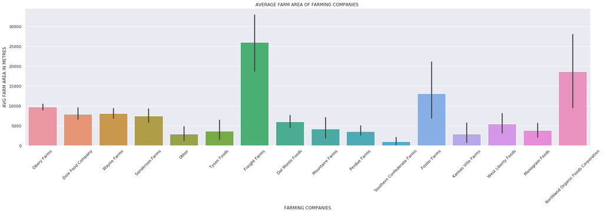

```python
#Bar Plot which depicts the avg farm area possessed
plt.figure(figsize = (28,7))
sns.barplot(x = 'farming_company', y = 'farm_area', data = farm_data)
plt.xlabel('FARMING COMPANIES')
plt.ylabel('AVG FARM AREA IN METRES')
plt.xticks(rotation= 45)

plt.title('AVERAGE FARM AREA OF FARMING COMPANIES ')
plt.show()
```

The above Bar Plot gives us a relation between the average farm area in square meters for production owned by the farming companies.

```python
# Which Farming Company Acquires more Farm Area ?
df1 = farm_data.groupby(['farming_company'])['farm_area'].sum().reset_index()
#df.reset_index()
df1.sort_values('farm_area', ascending = False)
```

|  | farming_company | farm_area |
| --- | --- | --- |
| 8 | Obery Farms | 5.321170e+06 |
| 14 | Wayne Farms | 2.256736e+06 |
| 11 | Sanderson Farms | 1.377516e+06 |
| 1 | Dole Food Company | 1.165857e+06 |
| 0 | Del Monte Foods | 9.412724e+05 |
| 3 | Freight Farms | 5.709372e+05 |
| 2 | Foster Farms | 3.001752e+05 |
| 7 | Northland Organic Foods Corporation | 1.864183e+05 |
| 9 | Other | 7.306022e+04 |
| 6 | Mountaire Farms | 5.505385e+04 |
| 5 | Monogram Foods | 4.584299e+04 |
| 13 | Tyson Foods | 4.015992e+04 |
| 15 | West Liberty Foods | 3.298595e+04 |
| 10 | Perdue Farms | 1.787686e+04 |
| 4 | Kansas Ville Farms | 1.155555e+04 |
| 12 | Southern Confederate Farms | 3.142908e+03 |

Farm companies 1)Obery Farms 2) Wayne Farms 3) Sanderson Farms 4) Dole Food Company & 5) Del Monte Foods which had an maximum occurence in the data tells us about the max amount of farming area/land they possess.

```python
# In Which Location the Farm Area is maximum
df2 = farm_data.groupby(['deidentified_location'])['farm_area'].sum().reset_index()
#df.reset_index()
df2.sort_values('farm_area', ascending = False)
```

|  | deidentified_location | farm_area |
| --- | --- | --- |
| 4 | location 5290 | 1.916548e+06 |
| 1 | location 2532 | 1.836198e+06 |
| 13 | location 8421 | 1.668947e+06 |
| 6 | location 5489 | 1.248449e+06 |
| 3 | location 5150 | 9.667720e+05 |
| 5 | location 5410 | 9.012861e+05 |
| 12 | location 7369 | 8.427637e+05 |
| 9 | location 5833 | 7.851918e+05 |
| 2 | location 4525 | 4.509993e+05 |
| 10 | location 6364 | 3.936769e+05 |
| 7 | location 565 | 3.754897e+05 |
| 15 | location 959 | 3.079848e+05 |
| 11 | location 7048 | 2.653486e+05 |
| 0 | location 1784 | 1.983086e+05 |
| 8 | location 5677 | 1.932247e+05 |
| 14 | location 868 | 4.857127e+04 |

Weather Data -

```python
#The Avg Pressure Sea level and Avg Observed temp at different locations.
df3 = train_weather.groupby(['deidentified_location'])['pressure_sea_level','temp_obs'].mean().reset_index()
#df.reset_index()
df3.sort_values('pressure_sea_level', ascending = False)
```

|  | deidentified_location | pressure_sea_level | temp_obs |
| --- | --- | --- | --- |
| 8 | location 5677 | 1017.988378 | 22.836021 |
| 12 | location 7369 | 1017.988378 | 22.836021 |
| 4 | location 5290 | 1017.938692 | 15.520579 |
| 7 | location 565 | 1017.527954 | 15.141678 |
| 3 | location 5150 | 1016.980579 | 9.357618 |
| 9 | location 5833 | 1016.887750 | 15.236366 |
| 13 | location 8421 | 1016.625114 | 21.367499 |
| 5 | location 5410 | 1016.377985 | 13.258409 |
| 15 | location 959 | 1015.989795 | 11.711801 |
| 1 | location 2532 | 1015.895371 | 9.879617 |
| 0 | location 1784 | 1015.668788 | 11.644679 |
| 2 | location 4525 | 1015.252010 | 7.888867 |
| 14 | location 868 | 1015.252010 | 7.888867 |
| 11 | location 7048 | 1014.425474 | 9.843232 |
| 6 | location 5489 | 1011.679311 | 24.940321 |
| 10 | location 6364 | NaN | 10.867931 |

● The above data represents the **Avg Sea Level Pressure** measured in Millibars and **Avg Temperature Observed** in Centigrade w.r.t the Locations.

● The Atmospheric Pressure(atm) is the unit of measurement = the average air pressure level at temp 15

[output not shown]

● Pressure Sea level is an indication of weather - Low pressure system leads to cloudiness,wind direction & precipitation.

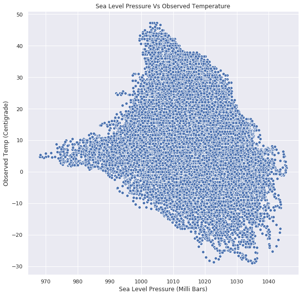

```python
# Scatter plot to display the relation between the 'pressure_sea_level'  and 'temp_obs'
plt.figure(figsize=(10,10))
sns.set(style="darkgrid")
sns.scatterplot(x ='pressure_sea_level', y = 'temp_obs', data= train_weather)
plt.title("Sea Level Pressure Vs Observed Temperature")
plt.xlabel('Sea Level Pressure (Milli Bars)')
plt.ylabel('Observed Temp (Centigrade)')

plt.show()
```

● The above scatter plot shows us the relationship between the two variables of weather data - Shows how the Temperature affects sea level pressure w.r.t the locations.

```python
#The Maximum percipitation and dew point temp at the deidentified locations
df4 = train_weather.groupby(['deidentified_location'])['precipitation','dew_temp'].max().reset_index()
#df.reset_index()
df4.sort_values('precipitation', ascending = False)
```

|  | deidentified_location | precipitation | dew_temp |
| --- | --- | --- | --- |
| 8 | location 5677 | 343.0 | 25.6 |
| 12 | location 7369 | 343.0 | 25.6 |
| 3 | location 5150 | 333.0 | 24.4 |
| 2 | location 4525 | 262.0 | 22.9 |
| 14 | location 868 | 262.0 | 22.9 |
| 1 | location 2532 | 216.0 | 25.0 |
| 13 | location 8421 | 203.0 | 26.1 |
| 4 | location 5290 | 198.0 | 26.1 |
| 7 | location 565 | 198.0 | 24.4 |
| 5 | location 5410 | 150.0 | 25.6 |
| 6 | location 5489 | 132.0 | 23.3 |
| 9 | location 5833 | 124.0 | 18.3 |
| 0 | location 1784 | 79.0 | 15.0 |
| 10 | location 6364 | NaN | 19.0 |
| 11 | location 7048 | NaN | 18.3 |
| 15 | location 959 | NaN | 20.7 |

● The above data represents the **Max Precipitation** measured as (mm/day) & **Max Dew Point Temp** in Celcius at different locations.

● dew_temp is the temp which needs to be cooled at (constant pressure) in order to achieve a Relative Humidity(RH) of 100%

● Humidity(Measure of Water Vapour in air - Gas)

When the temp drops sufficiently water vapour(Gas) condeses to water droplets(rainfall) usually as Precipitation.

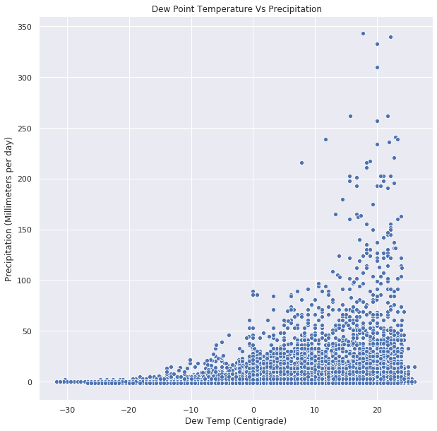

```python
## Scatter plot to display the relation between the 'dew_temp'  and 'precipitation'
plt.figure(figsize=(10,10))
sns.set(style="darkgrid")
sns.scatterplot(x ='dew_temp', y = 'precipitation', data= train_weather,markers=True,style_order=None )
plt.title(" Dew Point Temperature Vs Precipitation")
plt.xlabel('Dew Temp (Centigrade)')
plt.ylabel('Precipitation (Millimeters per day)')

plt.show()
```

● The above scatter plot shows us the relationship between another two variables of weather data which results in rainfall - It Shows how the Precipitation and Dew Temp are related w.r.t the locations.

● We can Observe few Outliers in the Precipitation which are above 100 mm per day.

```python
#The temp observed and dew point temp w.r.t the deidentified locations
df5 = train_weather.groupby(['deidentified_location'])['temp_obs','dew_temp'].max().reset_index()
#df.reset_index()
df5.sort_values('temp_obs', ascending = False)
```

|  | deidentified_location | temp_obs | dew_temp |
| --- | --- | --- | --- |
| 6 | location 5489 | 47.2 | 23.3 |
| 13 | location 8421 | 39.4 | 26.1 |
| 4 | location 5290 | 37.8 | 26.1 |
| 0 | location 1784 | 37.2 | 15.0 |
| 7 | location 565 | 37.2 | 24.4 |
| 8 | location 5677 | 36.1 | 25.6 |
| 12 | location 7369 | 36.1 | 25.6 |
| 1 | location 2532 | 35.6 | 25.0 |
| 5 | location 5410 | 35.6 | 25.6 |
| 9 | location 5833 | 35.0 | 18.3 |
| 2 | location 4525 | 33.9 | 22.9 |
| 3 | location 5150 | 33.9 | 24.4 |
| 14 | location 868 | 33.9 | 22.9 |
| 15 | location 959 | 32.9 | 20.7 |
| 10 | location 6364 | 30.0 | 19.0 |
| 11 | location 7048 | 26.0 | 18.3 |

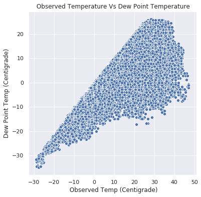

```python
#Scatter Plot to display the Correlation between 'temp_obs'  vs 'dew_temp'
plt.figure(figsize=(6,6))
sns.set(style="darkgrid")
sns.scatterplot(x='temp_obs', y = 'dew_temp',data = train_weather)
plt.title(" Observed Temperature Vs Dew Point Temperature")
plt.xlabel(' Observed Temp (Centigrade)')
plt.ylabel('Dew Point Temp (Centigrade)')
plt.show()
```

● The Above Plot displays the correlation between Observed temp and Dew Point temp .

● When the dew point temperature and air temperature are equal, the air is said to be totally saturated (Cannot hold any more water vapor), Creating the possibility of Rain.

● Dew point temperature is never greater than the air temperature which indicates air with lower relaitve humidity, Lower Humidity means much cooler than the actual temperature

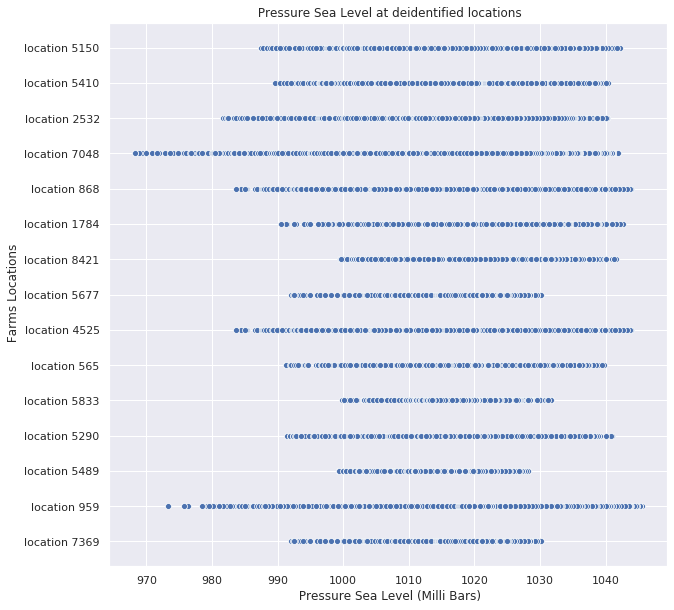

```python
#Plot between 'pressure_sea_level' vs 'deidentified locations'
plt.figure(figsize=(10,10))
sns.set(style="darkgrid")
sns.scatterplot(x ='pressure_sea_level', y = 'deidentified_location', data= train_weather,ci= 95,n_boot=1000,markers=True,
                style_order=None )
plt.title(" Pressure Sea Level at deidentified locations")
plt.xlabel(' Pressure Sea Level (Milli Bars)')
plt.ylabel(' Farms Locations')


plt.show()
```

● The above plot could be considered as an Variance Plot where you can observe some basic information such as minimum, maximum the range of the sea level pressure which are very useful. It gives a good indication how the values are spread.

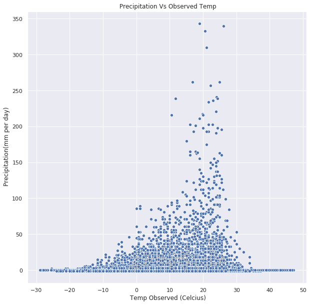

```python
#Plot between 'temp_obs' and 'precipitation'
plt.figure(figsize=(10,10))
sns.set(style="darkgrid")
sns.scatterplot(x ='temp_obs', y = 'precipitation', data= train_weather,ci= 95,n_boot=1000,markers=True,
                style_order=None )
plt.title(" Precipitation Vs Observed Temp")
plt.xlabel(' Temp Observed (Celcius)')
plt.ylabel(' Precipitation(mm per day)')


plt.show()
```

```python
#Observing the data of the factors which indicates precipitation
train_weather.groupby(['cloudiness' ,'wind_direction','wind_speed'])['precipitation'].describe()
```

| cloudiness | wind_direction | wind_speed | count | mean | std | min | 25% | 50% | 75% | max |
| --- | --- | --- | --- | --- | --- | --- | --- | --- | --- | --- |
| 0.0 | 0.0 | 0.0 | 5143.0 | 0.00175 | 0.235421 | -1.0 | 0.0 | 0.0 | 0.0 | 15.0 |
|  | 10.0 | 0.5 | 0.0 | NaN | NaN | NaN | NaN | NaN | NaN | NaN |
|  |  | 1.0 | 0.0 | NaN | NaN | NaN | NaN | NaN | NaN | NaN |
|  |  | 1.5 | 76.0 | 0.00000 | 0.000000 | 0.0 | 0.0 | 0.0 | 0.0 | 0.0 |
|  |  | 2.1 | 80.0 | 0.00000 | 0.000000 | 0.0 | 0.0 | 0.0 | 0.0 | 0.0 |
| ... | ... | ... | ... | ... | ... | ... | ... | ... | ... | ... |
| 9.0 | 360.0 | 6.7 | 1.0 | -1.00000 | NaN | -1.0 | -1.0 | -1.0 | -1.0 | -1.0 |
|  |  | 8.2 | 1.0 | 3.00000 | NaN | 3.0 | 3.0 | 3.0 | 3.0 | 3.0 |
|  |  | 8.8 | 2.0 | 11.00000 | 16.970563 | -1.0 | 5.0 | 11.0 | 17.0 | 23.0 |
|  |  | 9.3 | 1.0 | 13.00000 | NaN | 13.0 | 13.0 | 13.0 | 13.0 | 13.0 |
|  |  | 11.8 | 2.0 | 4.00000 | 1.414214 | 3.0 | 3.5 | 4.0 | 4.5 | 5.0 |

5159 rows × 8 columns

### 5) Missing values Treatment .

Train Data -

```python
train_data.isnull().sum()
```

```
date               0
farm_id            0
ingredient_type    0
dtype: int64
```

```python
train_data.shape
```

```
(20216100, 3)
```

Farm Data -

```python
# Finding Null Values Count in the Farm data
farm_data.isnull().sum()
```

```
farm_id                          0
operations_commencing_year     774
num_processing_plants         1094
farm_area                        0
farming_company                  0
deidentified_location            0
dtype: int64
```

```
farm_id                        0.00
operations_commencing_year    53.42
num_processing_plants         75.50
farm_area                      0.00
farming_company                0.00
deidentified_location          0.00
dtype: float64
```

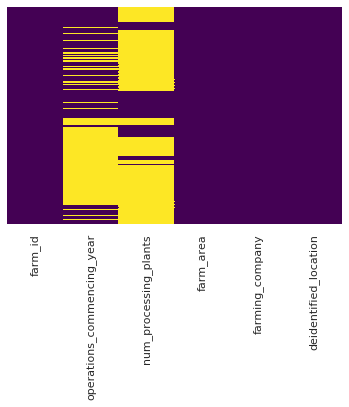

```python
#Nulls Plot
sns.heatmap(farm_data.isnull(),yticklabels=False, cbar=False,cmap='viridis' )

farm_data.isna().mean().round(4) * 100
```

```python
farm_data.shape
```

```
(1449, 6)
```

Weather Data -

```python
# Checking the Null Values in Train_Weather Data
train_weather.isnull().sum()
```

```
timestamp                    0
deidentified_location        0
temp_obs                    55
cloudiness               69173
wind_direction            6268
dew_temp                   113
pressure_sea_level       10618
precipitation            50289
wind_speed                 304
dtype: int64
```

```
timestamp                 0.00
deidentified_location     0.00
temp_obs                  0.04
cloudiness               49.49
wind_direction            4.48
dew_temp                  0.08
pressure_sea_level        7.60
precipitation            35.98
wind_speed                0.22
dtype: float64
```

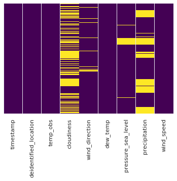

```python
#The single-line code will visualize the location of missing values.
sns.heatmap(train_weather.isnull(),yticklabels=False, cbar=False, cmap='viridis' )

train_weather.isna().mean().round(4) * 100
```

### 6) Outlier Treatment/Anamoly Detection

Weather Data -

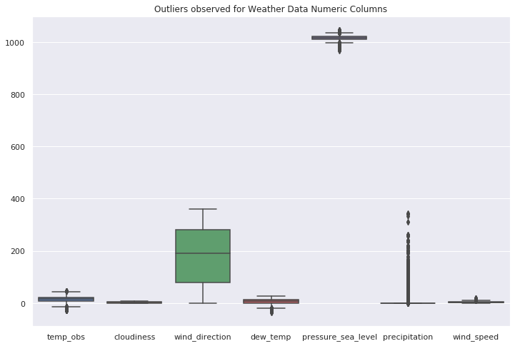

```python
#Boxplot for Outlier Detection in Weather Data
plt.figure(figsize=(12,8))
sns.set(style="darkgrid")
sns.boxplot(x= None , y=None, hue=None, data= train_weather, order=None, hue_order=None,
                  orient=None, color=None, palette=None, saturation=0.75, dodge=True, ax=None)
plt.title('Outliers observed for Weather Data Numeric Columns')
plt.show()
```

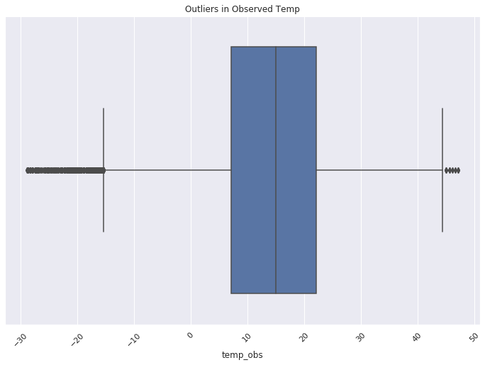

```python
#Individual Boxplot shows the normal range of the 'temp_obs'
plt.figure(figsize=(12,8))
sns.set(style="darkgrid")
sns.boxplot(x= train_weather['temp_obs'])
plt.title('Outliers in Observed Temp')
plt.xticks(rotation=45)
plt.show()
```

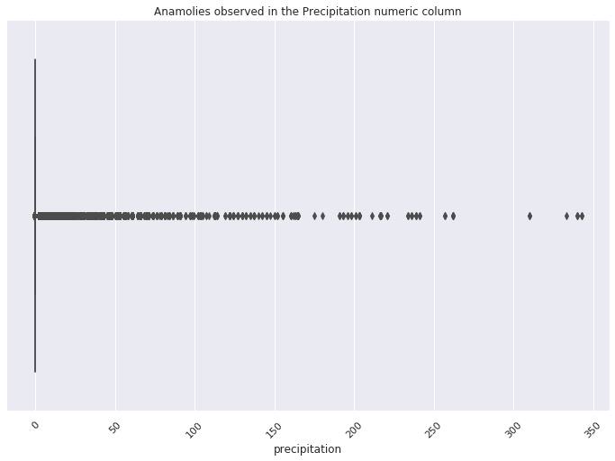

```python
#Individual Boxplot shows the anamolies observed in the 'precipitation'
plt.figure(figsize=(12,8))
sns.set(style="darkgrid")
sns.boxplot(x= train_weather['precipitation'])
plt.title('Anamolies observed in the Precipitation numeric column')
plt.xticks(rotation=45)
plt.show()
```

```python
train_weather.precipitation.max()
```

```
343.0
```

```python
train_weather.precipitation.min()
```

```
-1.0
```

## Insights from the EDA done above

### Observations :

#### On Type Conversions :

- The date and timestamp columns are read as object type , So they should be converted into datetime format.
- The 'farm_id' column read as object type actually consists of string values in it.
- Attributes like 'deidentified_location', 'farming_company' read as object type are nominal and have more than 2 levels. So along with label encoding, we need to convert them into equidistant levels.
- Columns in the weather data - 'temp_obs', 'dew_temp', 'wind_speed','cloudiness' etc read as float type needs to be converetd to integer int64 dataype

#### On Missing Values in the Data :

- The weather data consists of null values in the columns 'cloudiness','precipitation' and 'pressure_sea_level' which needs to be imputed and next the data needs to be standardized.
- The column 'num_processing_plants' in farm data with very high null value count needs to be imputed as it might provide information about the Field Management activities.